# Analysis and Visualization of WeRateDogs archive

As a dog lover, this has to be one of my favourite data analyis projects yet and I am so excited to share it with other data nerds who are dog lovers as well. I am still quite new to the field of data analysis and as I was learning the python libraries, my biggest challenge was having a structured syllabus that i could use to gain and improve my skills. When I stumbled upon the Udacity- ALX scholarship, it dawned on me that my dreams might finally come true and indeed they did. Long story short I completed the application and here I am...second project in the program. What I love most about this project is not only that it is about my favourite creatures but that it encompasses the whole data analysis process. Gathering, assessing, cleaning, storing, analysis, visualization and finally reporting.

Anyway, this article is meant to help me communicate my findings from the analysis I conducted. I was eager to find out how my favourite breed, chowchow is ranked so I did a quick visualization of the top 10 breeds because that's how confident I was my chochow was popular...and I was not at all disappointed. It came in 7th!

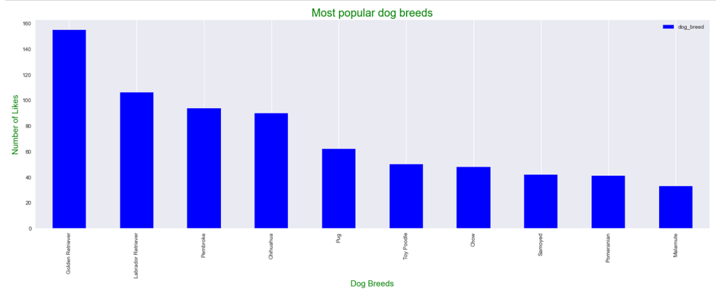

Among the top 5 breeds were the golden retreiver, labrador retriever, pembroke, chihuahua and pug.

### Likes vs Retweets

Well, I went ahead and tried to figure out the correlation between the different attributes in the dataset. There is a strong positive correlation between the likes and retweets(0.91). this indicates that users are likely to retweet posts they like so that more of their friends or people with similar interests can see them too. The probability that they'll like the photo too is very high as well as retweeting...and so the cycle continues. Below is a heat map that shows the correlation.

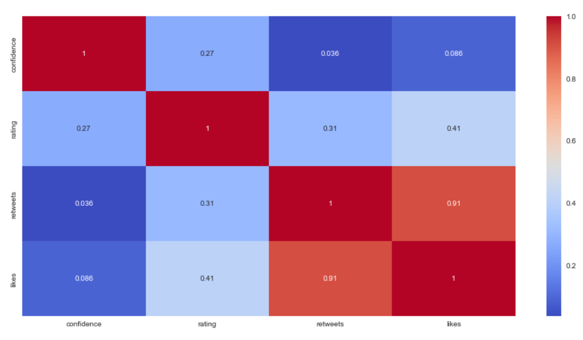

There is no clear realtionship between retweets and rating.

### Hashtags?

Finally I was curious whether or not the hashtags affected tweet engagement. An analysis of the same showed that there were only 24 tweets with hashtags, that is only 1.2% of the total tweets. This is a very small number to use to come to any meaningful conclusion. However, from the table below, it seems that tweets with hashtags have a relatively higher number of likes and retweets than those that do not.

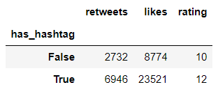

Well, that marks the end of my report. It does not however mean the end of my analysis. I will contnue doing an extensive analysis into the data to see what I can dig up. Until next time...cheers!